# Assignment 3

Arnav Murulidhar

9/22/2020

The libraries needed for the assignment:

```r
library(tidyverse)
library(ggplot2)
```

Then I’ll load the dataset from Assignment 1 and attach it to the search path

```r
tract_data <- read_csv("commutersLosAngelesCA2018.csv")
attach(tract_data)
```

### List of variables (from Assignment 1):

1. Property value (continuous) : VALP
2. Units in structure (categorical) : BLD
3. Total person’s income (continuous) : PINCP
4. Means of transportation to work (categorical) : JWTR
5. Travel time to work (continuous) : JWMNP

I found it much easier to read the data keeping the structure type and commute type labels as the numbers used by the Census bureau, as the long text labels cluttered up many of the tables. Instead, here is a key for easy translation:

Building Types

1. Mobile home or trailer
2. One-family house detached
3. One-family house attached
4. Two Apartments
5. 3-4 Apartments
6. 5-9 Apartments
7. 10-19 Apartments
8. 20-49 Apartments
9. 50 or more Apartments
10. Boat, RV, Van, etc.

Commute Types

```r
correlation <- cor.test(VALP, PINCP)

correlation
```

```
##
##  Pearson's product-moment correlation
##
## data:  VALP and PINCP
## t = 66.05, df = 24247, p-value < 2.2e-16
## alternative hypothesis: true correlation is not equal to 0
## 95 percent confidence interval:
##  0.379774 0.401109
## sample estimates:
##       cor
## 0.3904939
```

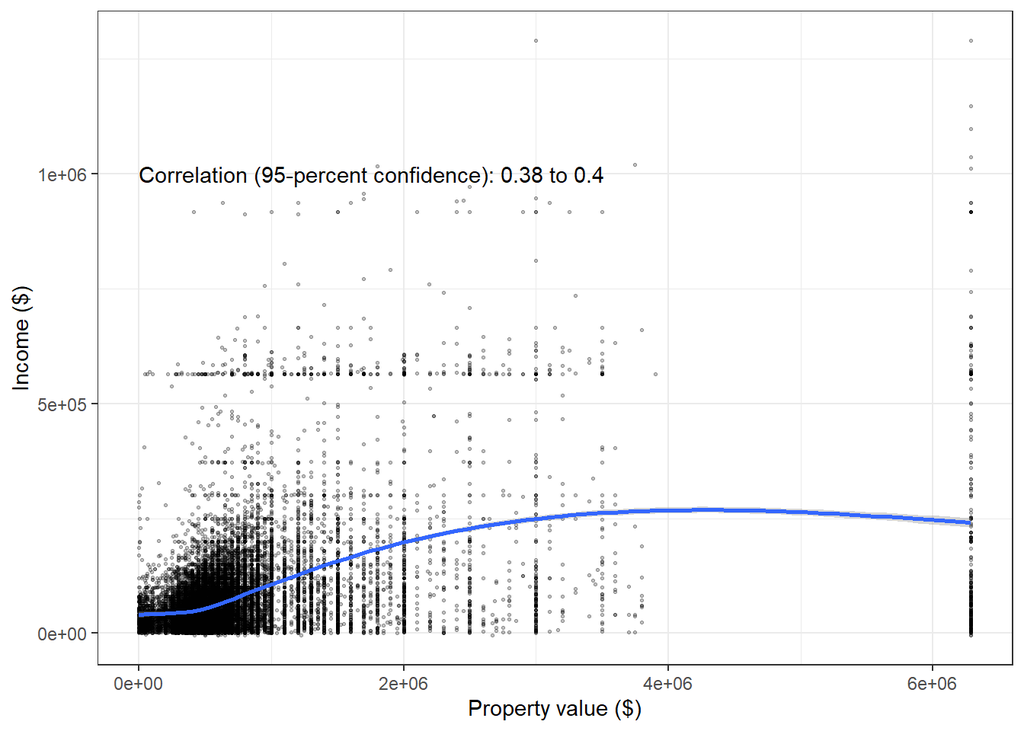

```r
ggplot(tract_data, aes(x = VALP, y = PINCP)) +
  geom_point(size = 0.5, alpha = 0.25, position = "jitter") +
  geom_smooth() +
  theme_bw() +
  scale_x_continuous(name = "Property value ($)") +
  scale_y_continuous(name = "Income ($)") +
  annotate(geom = "text", x = 0, y = 1000000,
           label = paste("Correlation (95-percent confidence):",
                         prettyNum(correlation$conf.int[1], digits = 2),
                         "to",
                         prettyNum(correlation$conf.int[2], digits = 2)),
           hjust = 0)
```

```r
correlation <- cor.test(VALP, JWMNP)

correlation
```

```
##
##  Pearson's product-moment correlation
##
## data:  VALP and JWMNP
## t = -5.0925, df = 24247, p-value = 3.561e-07
## alternative hypothesis: true correlation is not equal to 0
## 95 percent confidence interval:
##  -0.04525420 -0.02010808
## sample estimates:
##         cor
## -0.03268631
```

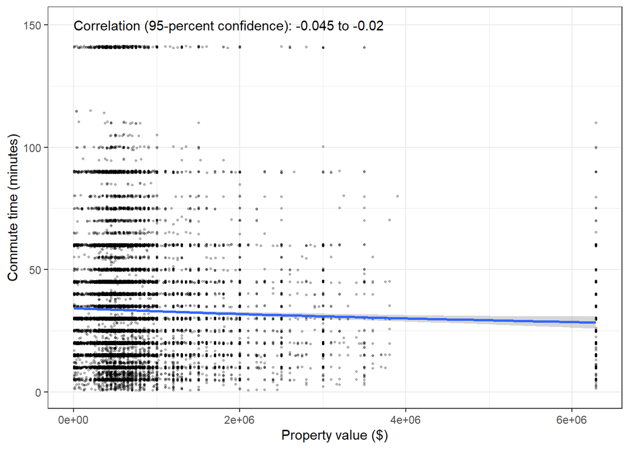

```r
ggplot(tract_data, aes(x = VALP, y = JWMNP)) +
  geom_point(size = 0.5, alpha = 0.25, position = "jitter") +
  geom_smooth() +
  theme_bw() +
  scale_x_continuous(name = "Property value ($)") +
  scale_y_continuous(name = "Commute time (minutes)") +
  annotate(geom = "text", x = 0, y = 150,
           label = paste("Correlation (95-percent confidence):",
                         prettyNum(correlation$conf.int[1], digits = 2),
                         "to",
                         prettyNum(correlation$conf.int[2], digits = 2)),
           hjust = 0)
```

The correlation is pretty weak but slightly negative.

```r
correlation <- cor.test(PINCP, JWMNP)

correlation
```

```
##
##  Pearson's product-moment correlation
##
## data:  PINCP and JWMNP
## t = 5.2874, df = 24247, p-value = 1.252e-07
## alternative hypothesis: true correlation is not equal to 0
## 95 percent confidence interval:
##  0.02135855 0.04650257
## sample estimates:
##        cor
## 0.03393593
```

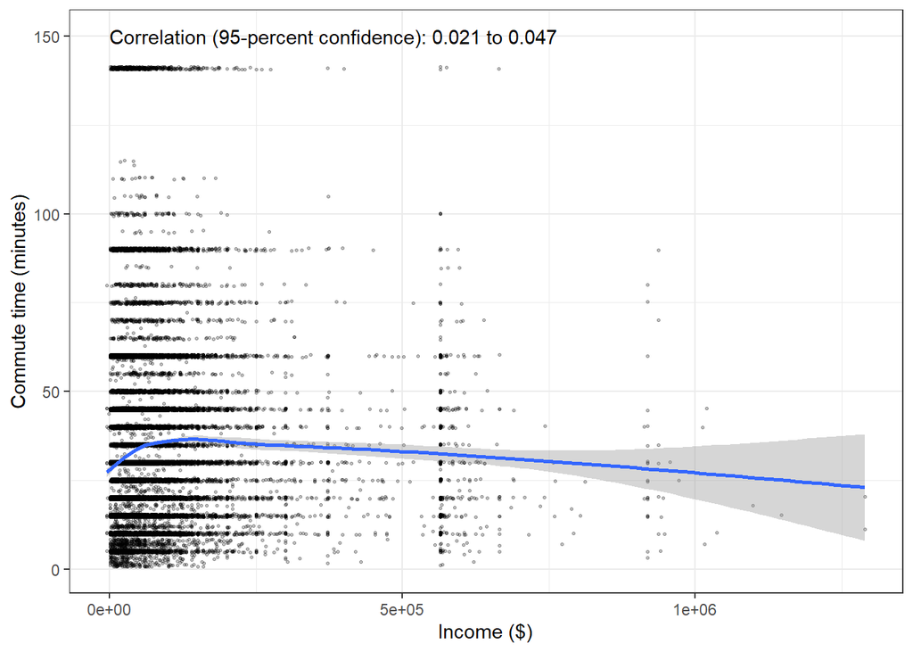

```r
ggplot(tract_data, aes(x = PINCP, y = JWMNP)) +
  geom_point(size = 0.5, alpha = 0.25, position = "jitter") +
  geom_smooth() +
  theme_bw() +
  scale_x_continuous(name = "Income ($)") +
  scale_y_continuous(name = "Commute time (minutes)") +
  annotate(geom = "text", x = 0, y = 150,
           label = paste("Correlation (95-percent confidence):",
                         prettyNum(correlation$conf.int[1], digits = 2),
                         "to",
                         prettyNum(correlation$conf.int[2], digits = 2)),
           hjust = 0)
```

```r
anova <- aov(VALP ~ BLD)

summary(anova)
```

```
##                Df    Sum Sq   Mean Sq F value Pr(>F)
## BLD             9 2.728e+14 3.031e+13   51.61 <2e-16 ***
## Residuals   24239 1.423e+16 5.872e+11
## ---
## Signif. codes:  0 '***' 0.001 '**' 0.01 '*' 0.05 '.' 0.1 ' ' 1
```

```r
differences <- TukeyHSD(anova)

as_tibble(cbind(pair = row.names(differences$BLD),
                differences$BLD))
```

```
## # A tibble: 45 x 5
##    pair  diff              lwr               upr               `p adj`
##    <chr> <chr>             <chr>             <chr>             <chr>
##  1 02-01 662586.015907661  548885.199959971  776286.831855351  0
##  2 03-01 469172.10956884   341992.671413089  596351.54772459   0
##  3 04-01 685291.508282502  474537.158697367  896045.857867638  0
##  4 05-01 573620.574041156  384450.114350333  762791.03373198   0
##  5 06-01 499714.929094661  297130.90384387   702298.954345453  0
##  6 07-01 511015.085389014  317776.025354865  704254.145423162  0
##  7 08-01 493955.461412821  317193.949361006  670716.973464637  0
##  8 09-01 498054.811753086  327712.665904952  668396.957601221  0
##  9 10-01 -32529.0322580367 -955796.879680864 890738.81516479   0.99999999995187
## 10 03-02 -193413.906338821 -255209.833542917 -131617.979134725 0
## # ... with 35 more rows
```

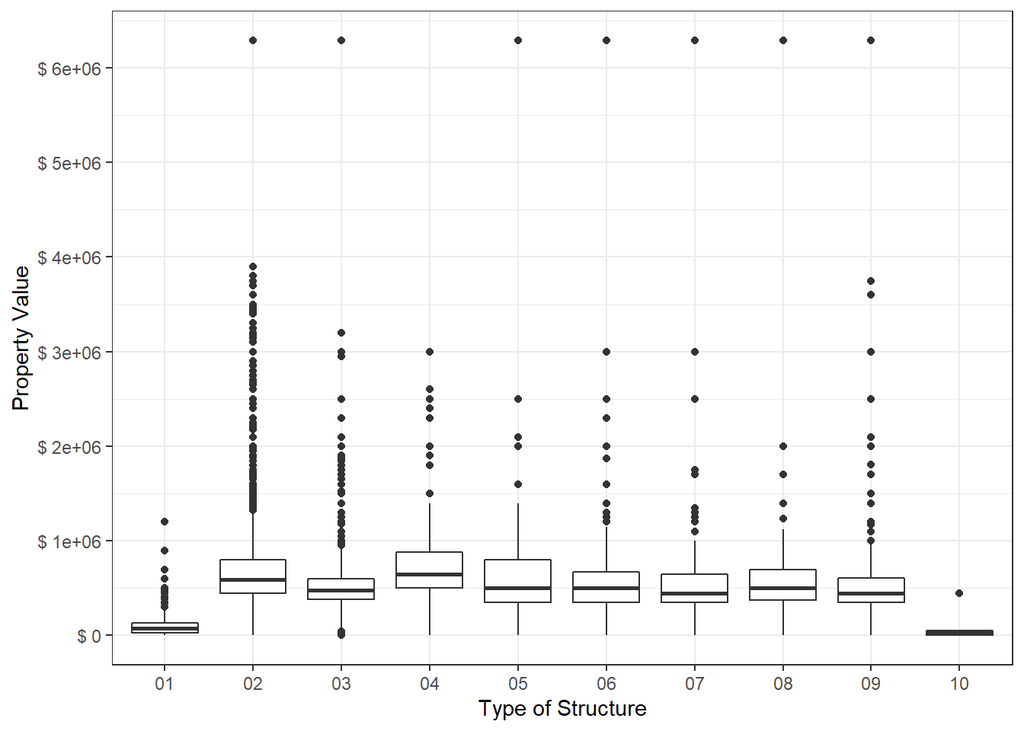

```r
ggplot(tract_data, aes(x = BLD, y = VALP)) +
  geom_boxplot() +
  theme_bw() +
  scale_x_discrete(name = "Type of Structure") +
  scale_y_continuous(name = "Property Value",
                     breaks = seq(0, 6000000, by = 1000000),
                     labels = paste("$",
                                    prettyNum(seq(0, 6000000, by = 1000000),
                                              big.mark = ",")))
```

```r
anova <- aov(VALP ~ JWTR)

summary(anova)
```

```
##                Df    Sum Sq   Mean Sq F value   Pr(>F)
## JWTR           10 2.722e+13 2.722e+12   4.557 1.74e-06 ***
## Residuals   24238 1.448e+16 5.974e+11
## ---
## Signif. codes:  0 '***' 0.001 '**' 0.01 '*' 0.05 '.' 0.1 ' ' 1
```

```r
differences <- TukeyHSD(anova)

as_tibble(cbind(pair = row.names(differences$JWTR),
                differences$JWTR))
```

```
## # A tibble: 55 x 5
##    pair  diff              lwr              upr              `p adj`
##    <chr> <chr>             <chr>            <chr>            <chr>
##  1 02-01 -114527.385830313 -224153.0427893~ -4901.728871322~ 0.0317811315482384
##  2 03-01 72698.0411145542  -645694.1857167~ 791090.267945814 0.999999868530642
##  3 04-01 -20514.1891012563 -232181.9895205~ 191153.611318055 0.999999913911943
##  4 05-01 -116319.200264693 -383563.2061750~ 150924.805645669 0.948487152602131
##  5 06-01 -244801.958885386 -2732783.367794~ 2243179.45002354 0.999999900148613
##  6 07-01 192420.263336884  -222562.6031532~ 607403.129827021 0.922701087871965
##  7 08-01 -142754.013680011 -434411.2899943~ 148903.262634366 0.892821095158487
##  8 09-01 125206.005716389  -109419.8217208~ 359831.833153661 0.826777757338441
##  9 10-01 203353.225060997  58528.9332434296 348177.516878565 0.0003233306154334~
## 10 12-01 90619.6737676207  -69182.94695059  250422.294485831 0.765182748173099
## # ... with 45 more rows
```

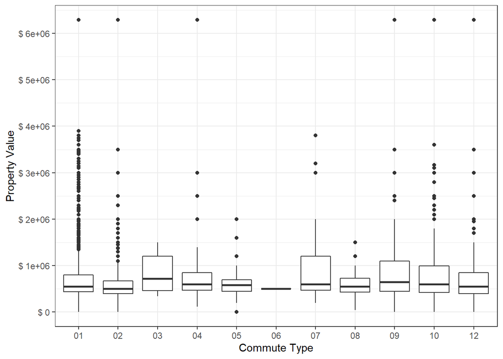

```r
ggplot(tract_data, aes(x = JWTR, y = VALP)) +
  geom_boxplot() +
  theme_bw() +
  scale_x_discrete(name = "Commute Type") +
  scale_y_continuous(name = "Property Value",
                     breaks = seq(0, 6000000, by = 1000000),
                     labels = paste("$",
                                    prettyNum(seq(0, 6000000, by = 1000000),
                                              big.mark = ",")))
```

```r
anova <- aov(PINCP ~ BLD)

summary(anova)
```

```
##                Df    Sum Sq   Mean Sq F value Pr(>F)
## BLD             9 1.079e+12 1.199e+11   12.06 <2e-16 ***
## Residuals   24239 2.409e+14 9.940e+09
## ---
## Signif. codes:  0 '***' 0.001 '**' 0.01 '*' 0.05 '.' 0.1 ' ' 1
```

```r
differences <- TukeyHSD(anova)

as_tibble(cbind(pair = row.names(differences$BLD),
                differences$BLD))
```

```
## # A tibble: 45 x 5
##    pair  diff              lwr              upr              `p adj`
##    <chr> <chr>             <chr>            <chr>            <chr>
##  1 02-01 39066.3296545924  24273.3831518184 53859.2761573665 0
##  2 03-01 28035.7636993424  11489.1926900681 44582.3347086167 3.27598446325794e-~
##  3 04-01 23869.6123220085  -3550.400389898~ 51289.6250339155 0.152476464355632
##  4 05-01 35728.2873592545  11116.4280090193 60340.1467094898 0.0001886924897724~
##  5 06-01 45284.5416861587  18927.521968461  71641.5614038564 2.00793612459282e-~
##  6 07-01 39467.9641275988  14326.763042053  64609.1652131446 2.96662987511187e-~
##  7 08-01 51736.1571389716  28738.753208863  74733.5610690802 0
##  8 09-01 54680.8792044846  32518.6613725696 76843.0970363997 0
##  9 10-01 -674.850998458191 -120795.8172450~ 119446.115248088 1
## 10 03-02 -11030.5659552501 -19070.47171670~ -2990.660193799~ 0.0006001693408503~
## # ... with 35 more rows
```

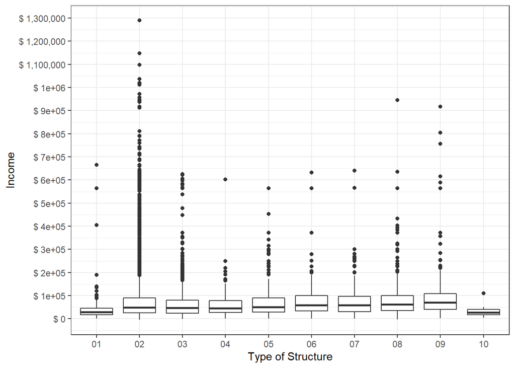

```r
ggplot(tract_data, aes(x = BLD, y = PINCP)) +
  geom_boxplot() +
  theme_bw() +
  scale_x_discrete(name = "Type of Structure") +
  scale_y_continuous(name = "Income",
                     breaks = seq(0, 1500000, by = 100000),
                     labels = paste("$",
                                    prettyNum(seq(0, 1500000, by = 100000),
                                              big.mark = ",")))
```

```r
anova <- aov(PINCP ~ JWTR)

summary(anova)
```

```
##                Df    Sum Sq   Mean Sq F value   Pr(>F)
## JWTR           10 6.758e+11 6.758e+10   6.788 1.18e-10 ***
## Residuals   24238 2.413e+14 9.957e+09
## ---
## Signif. codes:  0 '***' 0.001 '**' 0.01 '*' 0.05 '.' 0.1 ' ' 1
```

```r
differences <- TukeyHSD(anova)

as_tibble(cbind(pair = row.names(differences$JWTR),
                differences$JWTR))
```

```
## # A tibble: 55 x 5
##    pair  diff              lwr               upr               `p adj`
##    <chr> <chr>             <chr>             <chr>             <chr>
##  1 02-01 -29930.1149537337 -44083.2443291249 -15776.9855783424 0
##  2 03-01 -3577.11368871875 -96324.5453636024 89170.3179861649  0.99999999999085
##  3 04-01 5925.99182687     -21401.2037133097 33253.1873670497  0.999814273266522
##  4 05-01 18035.8173457568  -16466.4980370563 52538.13272857    0.844776597848954
##  5 06-01 -11535.4470220553 -332744.220047049 309673.326002938  0.999999999995516
##  6 07-01 -14113.2247998373 -67689.2430507723 39462.7934510977  0.998956690082044
##  7 08-01 6495.10092315546  -31159.069455005  44149.2713013159  0.999977634786219
##  8 09-01 24777.4733319401  -5513.69921510463 55068.6458789849  0.231621735197228
##  9 10-01 -9842.57076787038 -28539.9906570868 8854.84912134606  0.838835301855021
## 10 12-01 -17484.0184506297 -38115.2030500295 3147.16614877008  0.187301025372361
## # ... with 45 more rows
```

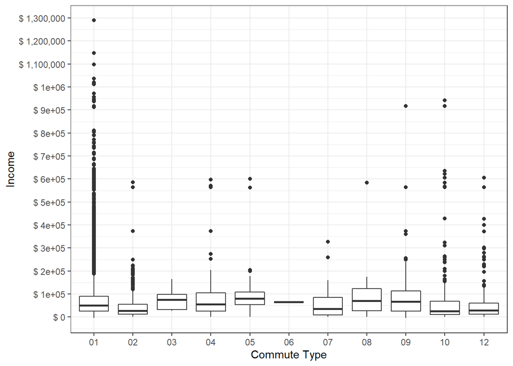

```r
ggplot(tract_data, aes(x = JWTR, y = PINCP)) +
  geom_boxplot() +
  theme_bw() +
  scale_x_discrete(name = "Commute Type") +
  scale_y_continuous(name = "Income",
                     breaks = seq(0, 1500000, by = 100000),
                     labels = paste("$",
                                    prettyNum(seq(0, 1500000, by = 100000),
                                              big.mark = ",")))
```

```r
anova <- aov(JWMNP ~ BLD)

summary(anova)
```

```
##                Df   Sum Sq Mean Sq F value Pr(>F)
## BLD             9     7235   803.9   1.337  0.212
## Residuals   24239 14574685   601.3
```

```r
differences <- TukeyHSD(anova)

as_tibble(cbind(pair = row.names(differences$BLD),
                differences$BLD))
```

```
## # A tibble: 45 x 5
##    pair  diff               lwr               upr              `p adj`
##    <chr> <chr>              <chr>             <chr>            <chr>
##  1 02-01 1.99307201277248   -1.64529930953933 5.63144333508429 0.776590228326729
##  2 03-01 1.49097265301869   -2.57870808512567 5.56065339116306 0.978245730826441
##  3 04-01 2.75350188898523   -3.99053574339039 9.49753952136084 0.955736384712751
##  4 05-01 -0.90966048598834  -6.96302404218556 5.14370307020888 0.99998140475008
##  5 06-01 2.38475923328591   -4.09783195735317 8.867350423925   0.977630572029409
##  6 07-01 1.39626818469254   -4.78728862199036 7.57982499137543 0.999434441226089
##  7 08-01 0.475568259153     -5.18071495198666 6.13185147029266 0.999999885254277
##  8 09-01 4.32638452092069   -1.12448206494482 9.7772511067862  0.262188115595399
##  9 10-01 -1.82642089093715  -31.3705471214932 27.7177053396189 0.999999992579469
## 10 03-02 -0.502099359753785 -2.47953925322379 1.47534053371622 0.998553723703871
## # ... with 35 more rows
```

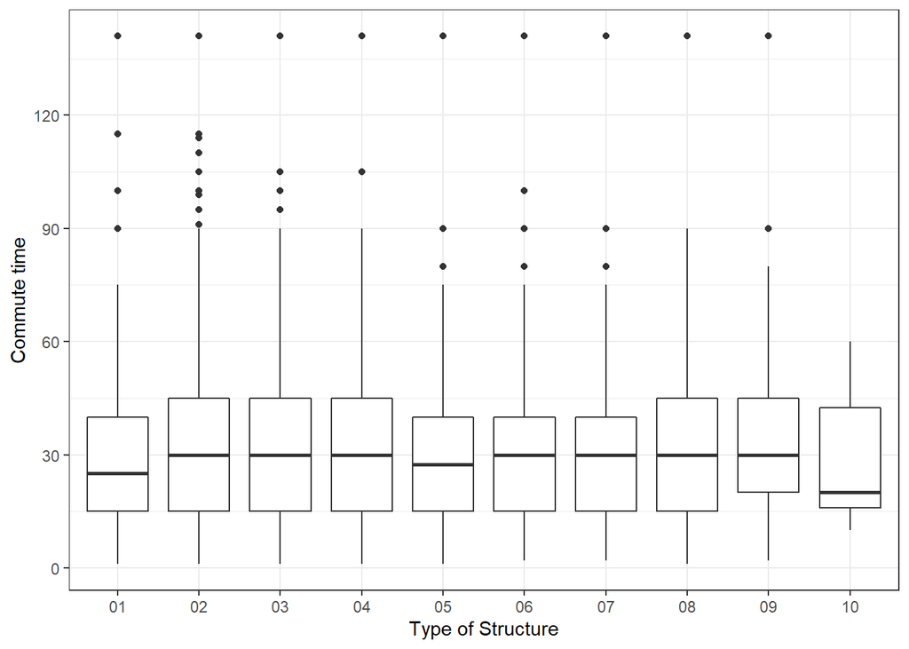

```r
ggplot(tract_data, aes(x = BLD, y = JWMNP)) +
  geom_boxplot() +
  theme_bw() +
  scale_x_discrete(name = "Type of Structure") +
  scale_y_continuous(name = "Commute time",
                     breaks = seq(0, 150, by = 30))
```

```r
anova <- aov(JWMNP ~ JWTR)

summary(anova)
```

```
##                Df   Sum Sq Mean Sq F value Pr(>F)
## JWTR           10   721261   72126   126.1 <2e-16 ***
## Residuals   24238 13860659     572
## ---
## Signif. codes:  0 '***' 0.001 '**' 0.01 '*' 0.05 '.' 0.1 ' ' 1
```

```r
differences <- TukeyHSD(anova)

as_tibble(cbind(pair = row.names(differences$JWTR),
                differences$JWTR))
```

```
## # A tibble: 55 x 5
##    pair  diff              lwr               upr               `p adj`
##    <chr> <chr>             <chr>             <chr>             <chr>
##  1 02-01 25.1360726015816  21.744244113921   28.5279010892423  0
##  2 03-01 6.079620988683    -16.1475043747868 28.3067463521528  0.998558256124436
##  3 04-01 28.3799807009296  21.8309583707715  34.9290030310877  0
##  4 05-01 42.4215750116623  34.1530194786962  50.6901305446285  0
##  5 06-01 12.3296209886833  -64.6487657649226 89.3080077422892  0.999988895558777
##  6 07-01 -1.75371234465126 -14.5933225919026 11.0858979026     0.999997577150826
##  7 08-01 -1.72517353186263 -10.7490780253762 7.29873096165089  0.999941553018857
##  8 09-01 -7.0420604272451  -14.3014063460603 0.217285491570094 0.06663473036629~
##  9 10-01 -19.7105127905709 -24.1913904639048 -15.229635117237  0
## 10 12-01 5.28472302950374  0.34041440330673  10.2290316557008  0.02459583681790~
## # ... with 45 more rows
```

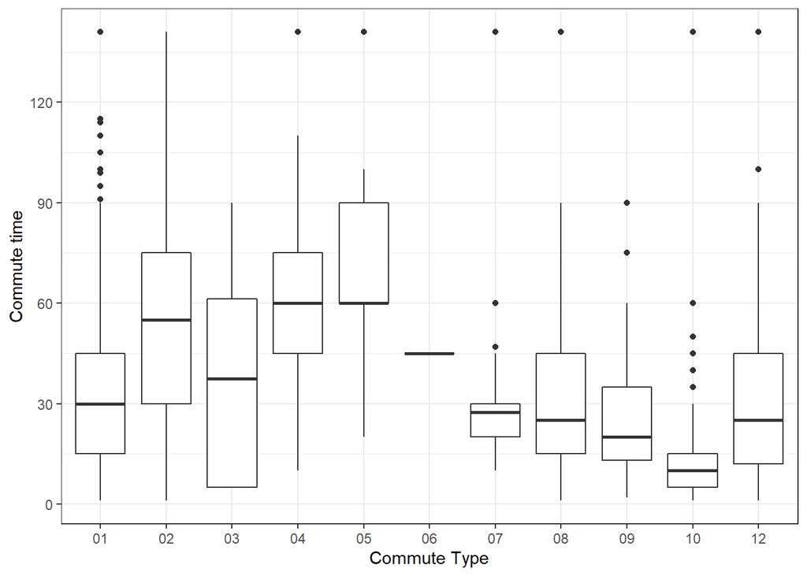

```r
ggplot(tract_data, aes(x = JWTR, y = JWMNP)) +
  geom_boxplot() +
  theme_bw() +
  scale_x_discrete(name = "Commute Type") +
  scale_y_continuous(name = "Commute time",
                     breaks = seq(0, 150, by = 30))
```

```r
chi_sq <- chisq.test(BLD, JWTR)
chi_sq
```

```
##
##  Pearson's Chi-squared test
##
## data:  BLD and JWTR
## X-squared = 176.07, df = 90, p-value = 1.58e-07
```

```r
chi_sq$observed
```

```
##     JWTR
## BLD     01    02    03    04    05    06    07    08    09    10    12
##   01   431    10     0     2     0     0     0     1     5     8     8
##   02 19329   432    12   105    75     1    32    66    81   220   201
##   03  1533    48     0    11     9     0     0     1     5    33    24
##   04   164     9     0     1     0     0     0     1     3     4     3
##   05   232     6     0     5     0     0     0     1     2     6     2
##   06   196     3     0     2     0     0     0     0     2     3     1
##   07   214     5     0     3     1     0     1     0     8     3     3
##   08   287     7     0     3     1     0     1     2     4     9     2
##   09   324     7     0     7     1     0     2     1     3    13     1
##   10     7     0     0     0     0     0     0     0     0     0     0
```